# Predicting Email Openings using Machine Learning

Our goal is to use features from the accounts and white label customer tables (such as EmailTemplateID, EmailStrategyID, and SubjectLine) to provide meaningful insight into our click and open rates. We will use a variety of techniques, such as regresssion, neural networks, clustering, and principal component analysis to model and predict these two metrics as part of a larger effort to construct a fully automated machine learning email strategy pipeline.  
- Lars Gartenberg

## We begin by importing our data

Displayed below are the first five of the quarter million entires we consider from our Email Accounts table:

```python
df = pd.read_csv(r"C:\Users\LG735620\Desktop\Data Science\Datasets\aggregateEmailDataExpansion2.csv")
df[:5]
```

|  | acctid | clientid | emailstrategyid | emailtemplateid | mastertemplate | name | subjectline | bannertext | AccountType | cdn | ... | TotalPayment | 1stPaymentAmount | 1stPaymentDate | LastPaymentDate | TotalTermInMonths | EmailType | EmailTreatmentStrategy | ContainsOffer | ContainsOfferTable | ContainsSettlement |
| --- | --- | --- | --- | --- | --- | --- | --- | --- | --- | --- | --- | --- | --- | --- | --- | --- | --- | --- | --- | --- | --- |
| 0 | 48427094 | AMXA74J4OS | O-E50H | I-REM3 | WLP2 | 3rd Reminder Email | Check out the payment options we have for you! | NaN | Digital Only | 3.77E+14 | ... | 0 | 0.0 | NaN | NaN | NaN | Proactive | Oasis | YES | YES | NO |
| 1 | 48427189 | AMXA74J5OS | O-E50L | I-REM3 | WLP2 | 3rd Reminder Email | Check out the payment options we have for you! | NaN | Digital + Calls | 3.77E+14 | ... | 0 | 0.0 | NaN | NaN | NaN | Proactive | Oasis | YES | YES | NO |
| 2 | 48427197 | AMXA74J5OS | O-E50L | I-REM3 | WLP2 | 3rd Reminder Email | Check out the payment options we have for you! | NaN | Digital + Calls | 3.77E+14 | ... | 0 | 0.0 | NaN | NaN | NaN | Proactive | Oasis | YES | YES | NO |
| 3 | 48368808 | AMX74JN0S | O-E38 | H-REM2O | Proactive - Oasis Terms and Conditions | Oasis Settlement 2 | Let�s review your payment options | NaN | Digital Only | 3.77E+14 | ... | 0 | 0.0 | NaN | NaN | NaN | Proactive | Oasis | YES | YES | NO |
| 4 | 48369342 | AMXA74J4IS | O-E50J | I-REM2 | WLP2 | 2nd Reminder Email | Important: Your exclusive settlement offer exp... | NaN | Digital Only | 3.79E+14 | ... | 0 | 0.0 | NaN | NaN | NaN | Proactive | Oasis | YES | YES | NO |

5 rows × 31 columns

Displayed below are the first 5 of a quarter million entires we consider from our WhiteLabel Customer table:

```python
wlAccounts = pd.read_csv(r"C:\Users\LG735620\Desktop\Data Science\Datasets\WhiteLabel Accounts.csv",sep='\t')
wlAccounts[:5]
```

|  | acctid | OasisEligible | CareEligible | ReInEligible | Decile | PreCharge |
| --- | --- | --- | --- | --- | --- | --- |
| 0 | 45775451 | YES | YES | NO | NaN | Y |
| 1 | 45775452 | YES | NO | NO | NaN | N |
| 2 | 45775453 | NO | NO | NO | NaN | Y |
| 3 | 45775454 | NO | NO | NO | NaN | N |
| 4 | 45775455 | YES | NO | NO | NaN | Y |

# Preliminary Data Exploration

Before building a predictive model, we must build up our intution for the data by looking at its distributions and averages.

```python
result.describe()
```

|  | acctid | AccountType | Opened | Clicked | SuccessfulLogin | ContainsOffer | ContainsOfferTable | ContainsSettlement | emailtemplateid_1 | emailtemplateid_2 | ... | name_5 | name_6 | subjectline_1 | subjectline_2 | subjectline_3 | subjectline_4 | subjectline_5 | EmailTreatmentStrategy_1 | EmailTreatmentStrategy_2 | EmailTreatmentStrategy_3 |
| --- | --- | --- | --- | --- | --- | --- | --- | --- | --- | --- | --- | --- | --- | --- | --- | --- | --- | --- | --- | --- | --- |
| count | 2.258550e+05 | 225855.000000 | 225855.000000 | 225855.000000 | 225855.000000 | 225855.000000 | 225855.000000 | 225855.000000 | 225855.000000 | 225855.000000 | ... | 225855.000000 | 225855.000000 | 225855.000000 | 225855.000000 | 225855.000000 | 225855.000000 | 225855.000000 | 225855.000000 | 225855.000000 | 225855.000000 |
| mean | 4.846832e+07 | 0.494671 | 0.228306 | 0.026039 | 0.258790 | 0.799287 | 0.788245 | 0.004454 | 0.014917 | 0.108189 | ... | 0.388360 | 0.716809 | 0.008860 | 0.179916 | 0.350862 | 0.338793 | 0.783928 | 0.073073 | 0.146576 | 0.807505 |
| std | 3.362904e+05 | 0.499973 | 0.419742 | 0.159251 | 0.437971 | 0.400535 | 0.408553 | 0.066591 | 0.121220 | 0.310620 | ... | 0.487378 | 0.450549 | 0.093708 | 0.384119 | 0.477241 | 0.473300 | 0.411565 | 0.260258 | 0.353684 | 0.394261 |
| min | 4.577546e+07 | 0.000000 | 0.000000 | 0.000000 | 0.000000 | 0.000000 | 0.000000 | 0.000000 | 0.000000 | 0.000000 | ... | 0.000000 | 0.000000 | 0.000000 | 0.000000 | 0.000000 | 0.000000 | 0.000000 | 0.000000 | 0.000000 | 0.000000 |
| 25% | 4.836969e+07 | 0.000000 | 0.000000 | 0.000000 | 0.000000 | 1.000000 | 1.000000 | 0.000000 | 0.000000 | 0.000000 | ... | 0.000000 | 0.000000 | 0.000000 | 0.000000 | 0.000000 | 0.000000 | 1.000000 | 0.000000 | 0.000000 | 1.000000 |
| 50% | 4.855663e+07 | 0.000000 | 0.000000 | 0.000000 | 0.000000 | 1.000000 | 1.000000 | 0.000000 | 0.000000 | 0.000000 | ... | 0.000000 | 1.000000 | 0.000000 | 0.000000 | 0.000000 | 0.000000 | 1.000000 | 0.000000 | 0.000000 | 1.000000 |
| 75% | 4.863986e+07 | 1.000000 | 0.000000 | 0.000000 | 1.000000 | 1.000000 | 1.000000 | 0.000000 | 0.000000 | 0.000000 | ... | 1.000000 | 1.000000 | 0.000000 | 0.000000 | 1.000000 | 1.000000 | 1.000000 | 0.000000 | 0.000000 | 1.000000 |
| max | 4.891610e+07 | 1.000000 | 1.000000 | 1.000000 | 1.000000 | 1.000000 | 1.000000 | 1.000000 | 1.000000 | 1.000000 | ... | 1.000000 | 1.000000 | 1.000000 | 1.000000 | 1.000000 | 1.000000 | 1.000000 | 1.000000 | 1.000000 | 1.000000 |

8 rows × 38 columns

Here, we observe that our email open rate sits at ~23% and that our email click rate is ~2.6%.  
Since the click rate is an order of magnitude lower, I had to take a different approach in building out the predicion architecture.  
I will write a follow up report detailing this second approach.

## Feature Histograms

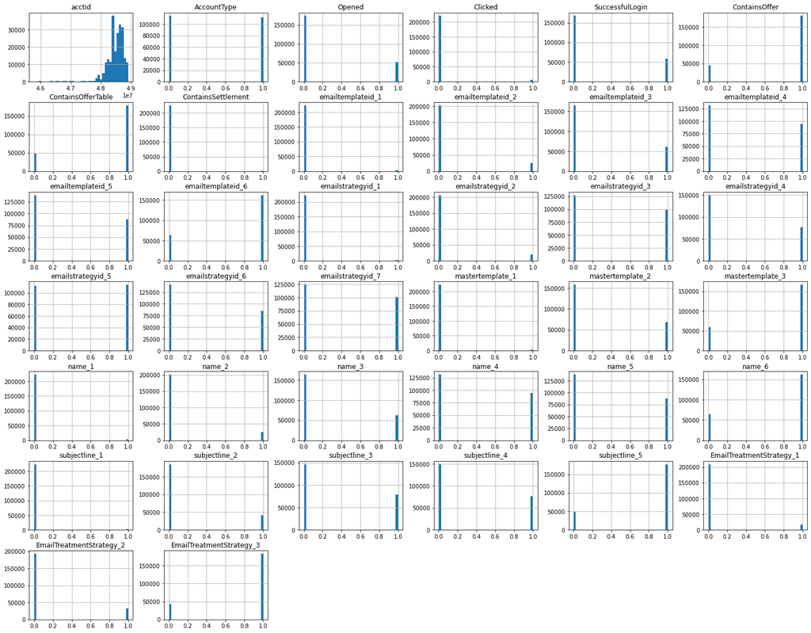

```python
result.hist(bins=40, figsize=(25,20))
plt.show()
```

## Correlation Matrix

A correlation matrix is a grid that pits each feature against every other feature, and calculates a coefficient in the unit domain [-1,1]. If the coefficient is 1, the two features perfectly map onto each other (i.e. the diagonal that compares each feature to itself). If the coefficient is 0, the two features in question have no correlation. If the feature is close to -1, there exists a strong negative correlation. Depending on the sterngth and magnitude of the coefficients with respect to 'Opened' and 'Clicked', we can observe which features have the strongest linear relationships to these two metrics.

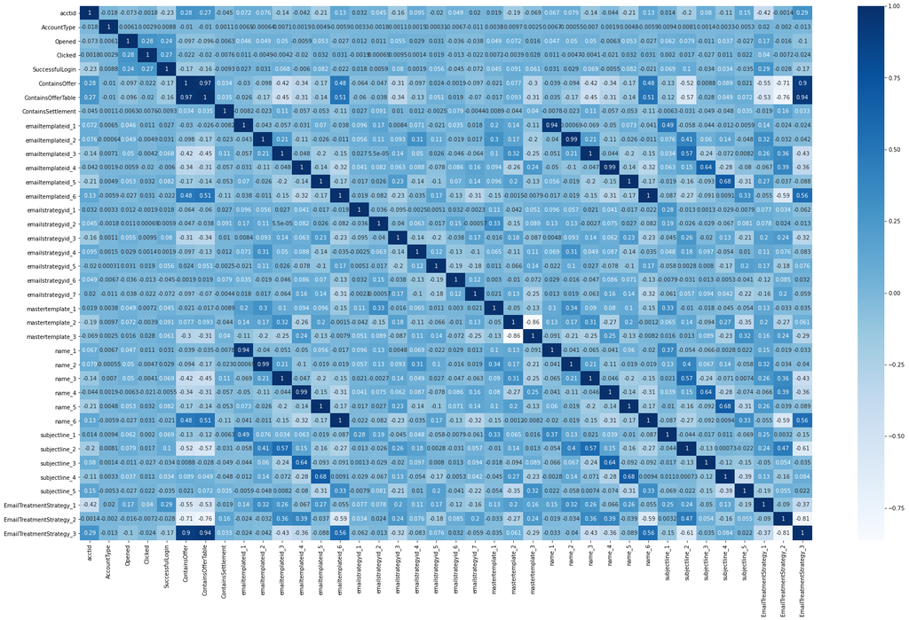

```python
plt.figure(figsize=(30,18))
corr = result.corr()
heatmap = sns.heatmap(corr, annot=True, cmap="Blues")
```

## Template ID, Strategies, and Subject Line Distributions

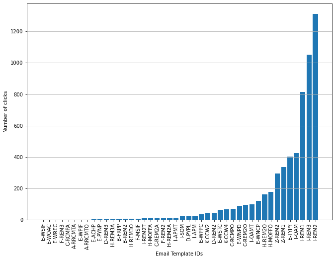

```python
data = [df['emailstrategyid'], df['emailtemplateid'],  df['Clicked'], df['subjectline']]
ndf = pd.DataFrame(data=[df['emailstrategyid'], df['emailtemplateid'],  df['Clicked'], df['subjectline']])
ndf = ndf.T
ls = ndf['emailstrategyid'].unique().tolist()
stratD = dict.fromkeys(ls, 0)
ls = ndf['emailtemplateid'].unique().tolist()
templateD = dict.fromkeys(ls, 0)
ls = ndf['subjectline'].unique().tolist()
subjectD = dict.fromkeys(ls, 0)

for index,row in ndf.iterrows():
    template = row['emailtemplateid']
    strat = row['emailstrategyid']
    subject = row['subjectline']
    click = row['Clicked']

    templateD[template] += int(click)
    stratD[strat] += int(click)
    subjectD[subject] += int(click)

D = templateD
D = dict(sorted(D.items(), key=lambda item: item[1]))
templateD = D
plt.figure(figsize=(11,8))
plt.bar(range(len(D)), list(D.values()), align='center')
plt.xticks(range(len(D)), list(D.keys()),fontsize = 10,rotation='vertical')
plt.xlabel("Email Template IDs")
plt.ylabel("Number of clicks")
axes = plt.gca()
axes.yaxis.grid()
plt.show()
```

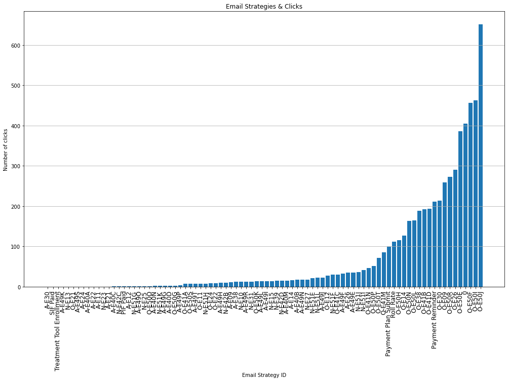

```python
D = stratD
D = dict(sorted(D.items(), key=lambda item: item[1]))
plt.figure(figsize=(17,10))
plt.bar(range(len(D)), list(D.values()), align='center')
plt.xticks(range(len(D)), list(D.keys()),fontsize = 12,rotation='vertical')
plt.title("Email Strategies & Clicks")
plt.xlabel("Email Strategy ID")
plt.ylabel("Number of clicks")
axes = plt.gca()
axes.yaxis.grid()
plt.show()
```

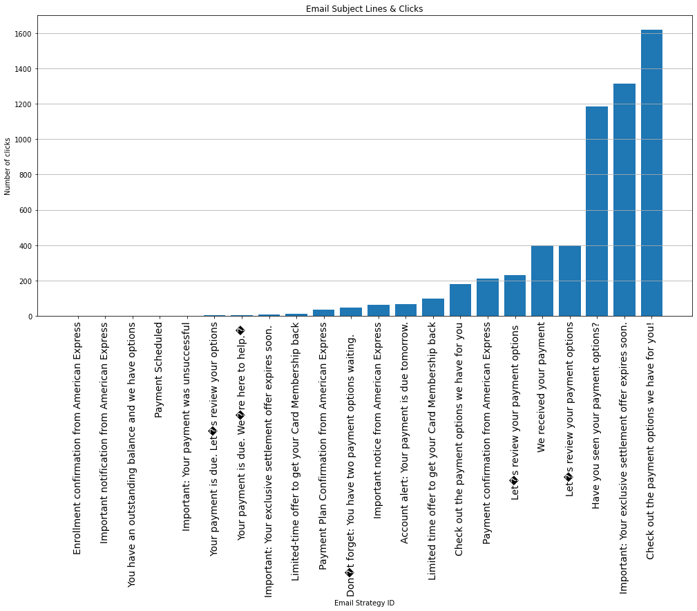

```python
D = subjectD
D = dict(sorted(D.items(), key=lambda item: item[1]))
plt.figure(figsize=(17,8))
plt.bar(range(len(D)), list(D.values()), align='center')
plt.xticks(range(len(D)), list(D.keys()),fontsize = 14,rotation='vertical')
plt.title("Email Subject Lines & Clicks")
plt.xlabel("Email Strategy ID")
plt.ylabel("Number of clicks")
axes = plt.gca()
axes.yaxis.grid()
plt.show()
```

# Data Cleaning

Before implementing Machine Learning, we have to clean our data in order to remove statistical noise, take into account the pull from outliers,  
and format data with respect to standards machine learning models require before training can occur.

## Step 1) Drop Irrelevant Columns & No Value Entries

```python
df = df.drop(['clientid'
              ,'PlanCreatedDate'
              ,'TotalPayment'
              ,'Delivered'
              ,'Bounced','Spam'
              ,'EmailType'
              ,'FailedLogin'
              ,'1stPaymentAmount'
              ,'1stPaymentDate'
              ,'LastPaymentDate'
              ,'TotalTermInMonths'
              ,'SentDate'
              ,'PlaceDate'
              ,'cdn'
              , 'bannertext'
              ,'emailaddress'], axis=1).dropna()
```

## Step 2) Clean Features using Binary Encoding

Binary Encoding is a method that turns categorical data into numerical data that machine learning models can understand.  
For example, if a column called temperature contained the values 'hot', 'warm', 'cool', and 'cold', Binary Encoding would turn  
the labels into their corresponding binary strings (eg. hot → 001, warm → 010, cool → 011, cold → 100), then split the strings into three columns.  
In this case, we will binary encode the following features:  
'emailtemplateid'  
'emailstrategyid'  
'mastertemplate'  
'name'  
'subjectline'  
'EmailTreatmentStrategy'

```python
featurestoBinarize = ['emailtemplateid','emailstrategyid','mastertemplate','name','subjectline','EmailTreatmentStrategy']

result = df

for feature in featurestoBinarize:
    eid = pd.DataFrame(df[feature])
    eid.columns =[feature]
    encoder = ce.BinaryEncoder(cols = [feature])
    eid_bin = encoder.fit_transform(eid[feature])
    eid = pd.concat([eid,eid_bin],axis = 1)
    result = pd.concat([result,eid_bin], axis=1)
    result = result.drop([feature], axis = 1)

# Map labels to 0 & 1 ints
result = result.replace({'AccountType': {'Digital + Calls': 1,  'Digital Only': 0}})
result = result.replace({'ContainsOffer': {'YES': 1,  'NO': 0}})
result = result.replace({'ContainsOfferTable': {'YES': 1, 'YES ':1,  'NO': 0}})
result = result.replace({'ContainsSettlement': {'YES': 1,  'NO': 0}})
result = result.replace({'Opened': {2: 1}})
result = result.replace({'Clicked': {2: 1}})

# Drop columns with a 0 in the column name
result = result[result.columns.drop(list(result.filter(regex='0')))]
```

## Store cleaned data in Result dataframe

```python
result.head()
```

|  | acctid | AccountType | Opened | Clicked | SuccessfulLogin | ContainsOffer | ContainsOfferTable | ContainsSettlement | emailtemplateid_1 | emailtemplateid_2 | ... | name_5 | name_6 | subjectline_1 | subjectline_2 | subjectline_3 | subjectline_4 | subjectline_5 | EmailTreatmentStrategy_1 | EmailTreatmentStrategy_2 | EmailTreatmentStrategy_3 |
| --- | --- | --- | --- | --- | --- | --- | --- | --- | --- | --- | --- | --- | --- | --- | --- | --- | --- | --- | --- | --- | --- |
| 0 | 48427094 | 0 | 0 | 0 | 0 | 1 | 1 | 0 | 0 | 0 | ... | 0 | 1 | 0 | 0 | 0 | 0 | 1 | 0 | 0 | 1 |
| 1 | 48427189 | 1 | 0 | 0 | 1 | 1 | 1 | 0 | 0 | 0 | ... | 0 | 1 | 0 | 0 | 0 | 0 | 1 | 0 | 0 | 1 |
| 2 | 48427197 | 1 | 0 | 0 | 0 | 1 | 1 | 0 | 0 | 0 | ... | 0 | 1 | 0 | 0 | 0 | 0 | 1 | 0 | 0 | 1 |
| 3 | 48368808 | 0 | 1 | 1 | 1 | 1 | 1 | 0 | 0 | 0 | ... | 1 | 0 | 0 | 0 | 0 | 1 | 0 | 0 | 0 | 1 |
| 4 | 48369342 | 0 | 0 | 0 | 0 | 1 | 1 | 0 | 0 | 0 | ... | 1 | 1 | 0 | 0 | 0 | 1 | 1 | 0 | 0 | 1 |

5 rows × 38 columns

## Step 3) Join the two databases on the shared Account Id feature

```python
ad = df['Opened'].to_frame()
ad['acctid'] = df['acctid']
wlAccounts = pd.merge(wlAccounts, ad, on='acctid')
wlAccounts = wlAccounts.drop(['acctid'],axis=1)

wlAccounts
```

|  | OasisEligible | CareEligible | ReInEligible | Decile | PreCharge | Opened |
| --- | --- | --- | --- | --- | --- | --- |
| 0 | YES | NO | NO | NaN | Y | 0 |
| 1 | YES | NO | NO | 10.0 | N | 0 |
| 2 | YES | NO | NO | 2.0 | N | 0 |
| 3 | YES | NO | NO | NaN | Y | 0 |
| 4 | YES | NO | NO | NaN | Y | 0 |
| ... | ... | ... | ... | ... | ... | ... |
| 225850 | YES | NO | NO | NaN | Y | 0 |
| 225851 | YES | NO | NO | NaN | Y | 0 |
| 225852 | YES | NO | NO | NaN | Y | 0 |
| 225853 | YES | NO | NO | NaN | Y | 0 |
| 225854 | YES | YES | NO | NaN | Y | 0 |

225855 rows × 6 columns

## Step 4) Convert YES / NOs into 1 / 0s

As previously mentioned, part of the cleaning process is turning label data into numerical data that machine learning models can understand.

```python
wlAccounts = wlAccounts.dropna()
wlAccounts = wlAccounts.replace({'OasisEligible': {'YES': 1,  'NO': 0}})
wlAccounts = wlAccounts.replace({'CareEligible': {'YES': 1,  'NO': 0}})
wlAccounts = wlAccounts.replace({'ReInEligible': {'YES': 1,  'NO': 0}})
wlAccounts = wlAccounts.replace({'PreCharge': {'Y': 1,  'N': 0}})
wlAccounts = wlAccounts.replace({'Opened': {0:'Unopened',  1:'Opened',  2:'Opened'}})
wlAccounts = wlAccounts.rename(columns={'Opened':'target'})
wlAccounts
```

[output not shown]

198991 rows × 6 columns

## Step 5) Scale Values down to Standard Length to Remove Statistical Variance

```python
features = ['OasisEligible', 'CareEligible', 'ReInEligible', 'Decile', 'PreCharge']
# Separating out the features
x = wlAccounts.loc[:, features].values
# Separating out the target
y = wlAccounts.loc[:,['target']].values
# Standardizing the features
x = StandardScaler().fit_transform(x)
x
```

```
array([[ 0.28346318, -0.08338371, -0.21249408,  1.09324321, -0.09924864],
       [ 0.28346318, -0.08338371, -0.21249408, -1.45846495, -0.09924864],
       [ 0.28346318, -0.08338371, -0.21249408, -0.18261087, -0.09924864],
       ...,
       [ 0.28346318, -0.08338371, -0.21249408,  0.45531617, -0.09924864],
       [ 0.28346318, 11.99275011, -0.21249408, -1.45846495, 10.07570519],
       [ 0.28346318, -0.08338371, -0.21249408, -0.82053791, -0.09924864]])
```

## Step 6) Apply Principal Component Analysis (PCA) to Reduce Dimensionality

Principal Component Analysis is a dimensionality-reduction method that is often used to reduce the number of features of large datasets, by transforming a set of vectors into a smaller set that retains the maximal amount of information about (i.e. "captures the essence of") the input features.  
In order to graphically interpret how our five features (OasisEligible, CareEligible, ReInEligible, Decile, PreCharge) correlate with the Opened feature, we apply PCA to transform 5 features down to 2 in order to plot them against each other.

```python
pca = PCA(n_components=2)
principalComponents = pca.fit_transform(x)
principalDf = pd.DataFrame(data = principalComponents, columns = ['principal component 1', 'principal component 2'])
finalDf = pd.concat([principalDf, wlAccounts[['target']]], axis = 1).dropna()
```

Displayed below is the reduced dataset after applying PCA:

```python
finalDf
```

|  | principal component 1 | principal component 2 | target |
| --- | --- | --- | --- |
| 1 | -0.006931 | 0.939599 | Unopened |
| 2 | -0.114725 | 0.075859 | Unopened |
| 13 | 0.020018 | 1.155533 | Opened |
| 14 | 0.020018 | 1.155533 | Opened |
| 15 | 0.020018 | 1.155533 | Unopened |
| ... | ... | ... | ... |
| 198986 | -0.114725 | 0.075859 | Unopened |
| 198987 | -0.195571 | -0.571945 | Opened |
| 198988 | -0.168622 | -0.356011 | Unopened |
| 198989 | 15.668968 | -0.100719 | Opened |
| 198990 | -0.060828 | 0.507729 | Opened |

176725 rows × 3 columns

## Step 7) Clustering

After properly cleaning and reducing the dataset into a two-dimensional matrix, we can plot the two princial components against each other and color the opened & unopened emails accordingly:

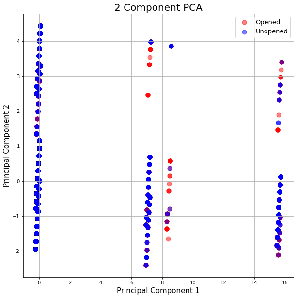

```python
fig = plt.figure(figsize = (10,10))
ax = fig.add_subplot(1,1,1)
ax.set_xlabel('Principal Component 1', fontsize = 15)
ax.set_ylabel('Principal Component 2', fontsize = 15)
ax.set_title('2 Component PCA', fontsize = 20)
targets = ['Unopened', 'Opened']
targets1 = ['Opened', 'Unopened']
colors = ['r','b']
for target, color in zip(targets,colors):
    indicesToKeep = finalDf['target'] == target
    ax.scatter(finalDf.loc[indicesToKeep, 'principal component 1']
               , finalDf.loc[indicesToKeep, 'principal component 2']
               , c = color
               , s = 80
               , alpha = 0.5)
ax.legend(targets1,prop={'size': 13})
ax.grid()
```

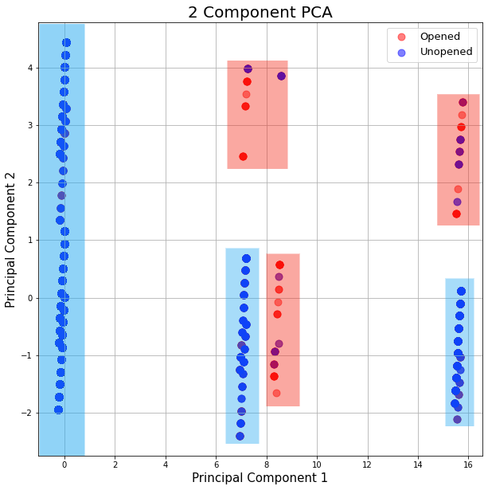

```python
Image(filename=r"C:\Users\LG735620\Desktop\pca colored.png")
```